# R Notebook

```r
# library
library(tidyverse)
library(reshape2)
library(caret)
library(nnet)

# dataset
df = read_csv(here::here(
  "Sleep_health_and_lifestyle_dataset.csv"))
df = janitor::clean_names(df)
```

## Data Exploration

```r
skimr::skim(df)
```

```
── Data Summary ────────────────────────
                           Values
Name                       df
Number of rows             374
Number of columns          13
_______________________
Column type frequency:
  character                5
  numeric                  8
________________________
Group variables            None
```

|  | skim_variable | n_missing | complete_rate | min | max | empty | n_unique | whitespace |
| --- | --- | --- | --- | --- | --- | --- | --- | --- |
| 1 | gender | 0 | 1 | 4 | 6 | 0 | 2 | 0 |
| 2 | occupation | 0 | 1 | 5 | 20 | 0 | 11 | 0 |
| 3 | bmi_category | 0 | 1 | 5 | 13 | 0 | 4 | 0 |
| 4 | blood_pressure | 0 | 1 | 6 | 6 | 0 | 25 | 0 |
| 5 | sleep_disorder | 0 | 1 | 4 | 11 | 0 | 3 | 0 |

|  | skim_variable | n_missing | complete_rate | mean | sd | p0 | p25 | p50 | p75 | p100 | hist |
| --- | --- | --- | --- | --- | --- | --- | --- | --- | --- | --- | --- |
| 1 | person_id | 0 | 1 | 187.500000 | 108.1087416 | 1.0 | 94.25 | 187.5 | 280.75 | 374.0 | ▇▇▇▇▇ |
| 2 | age | 0 | 1 | 42.184492 | 8.6731335 | 27.0 | 35.25 | 43.0 | 50.00 | 59.0 | ▆▆▇▃▅ |
| 3 | sleep_duration | 0 | 1 | 7.132086 | 0.7956567 | 5.8 | 6.40 | 7.2 | 7.80 | 8.5 | ▇▆▇▇▆ |
| 4 | quality_of_sleep | 0 | 1 | 7.312834 | 1.1969559 | 4.0 | 6.00 | 7.0 | 8.00 | 9.0 | ▁▇▆▇▅ |
| 5 | physical_activity_level | 0 | 1 | 59.171123 | 20.8308037 | 30.0 | 45.00 | 60.0 | 75.00 | 90.0 | ▇▇▇▇▇ |
| 6 | stress_level | 0 | 1 | 5.385027 | 1.7745264 | 3.0 | 4.00 | 5.0 | 7.00 | 8.0 | ▇▃▂▃▃ |
| 7 | heart_rate | 0 | 1 | 70.165775 | 4.1356755 | 65.0 | 68.00 | 70.0 | 72.00 | 86.0 | ▇▇▂▁▁ |
| 8 | daily_steps | 0 | 1 | 6816.844920 | 1617.9156791 | 3000.0 | 5600.00 | 7000.0 | 8000.00 | 10000.0 | ▁▅▇▆▂ |

```r
glimpse(df)
```

```
Rows: 374
Columns: 13
$ person_id               <dbl> 1, 2, 3, 4, 5, 6, 7, 8, 9, 10, 11, 12, 13, 14, 15,…
$ gender                  <chr> "Male", "Male", "Male", "Male", "Male", "Male", "M…
$ age                     <dbl> 27, 28, 28, 28, 28, 28, 29, 29, 29, 29, 29, 29, 29…
$ occupation              <chr> "Software Engineer", "Doctor", "Doctor", "Sales Re…
$ sleep_duration          <dbl> 6.1, 6.2, 6.2, 5.9, 5.9, 5.9, 6.3, 7.8, 7.8, 7.8, …
$ quality_of_sleep        <dbl> 6, 6, 6, 4, 4, 4, 6, 7, 7, 7, 6, 7, 6, 6, 6, 6, 5,…
$ physical_activity_level <dbl> 42, 60, 60, 30, 30, 30, 40, 75, 75, 75, 30, 75, 30…
$ stress_level            <dbl> 6, 8, 8, 8, 8, 8, 7, 6, 6, 6, 8, 6, 8, 8, 8, 8, 7,…
$ bmi_category            <chr> "Overweight", "Normal", "Normal", "Obese", "Obese"…
$ blood_pressure          <chr> "126/83", "125/80", "125/80", "140/90", "140/90", …
$ heart_rate              <dbl> 77, 75, 75, 85, 85, 85, 82, 70, 70, 70, 70, 70, 70…
$ daily_steps             <dbl> 4200, 10000, 10000, 3000, 3000, 3000, 3500, 8000, …
$ sleep_disorder          <chr> "None", "None", "None", "Sleep Apnea", "Sleep Apne…
```

**Let’s look at the distribution of each variables, starting with the categorical variables.**

- Gender

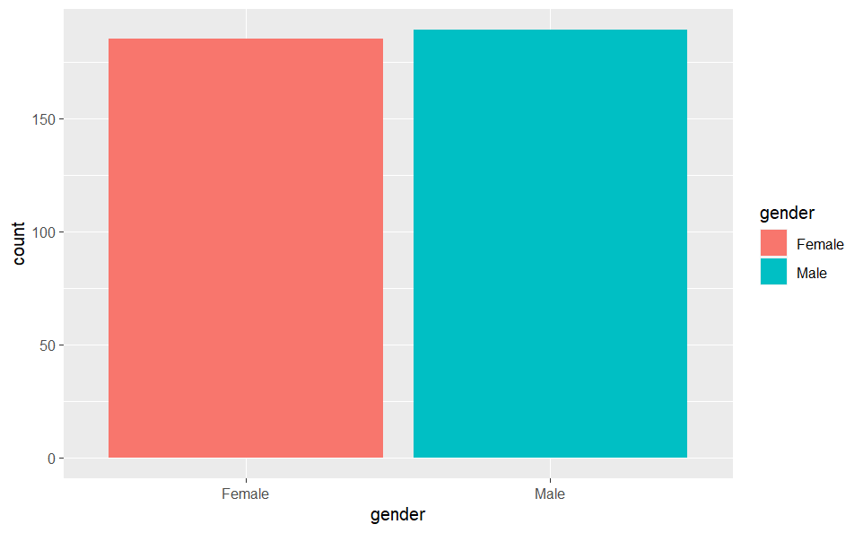

```r
df %>% ggplot(aes(gender, fill=gender)) + geom_bar()
```

- Occupation

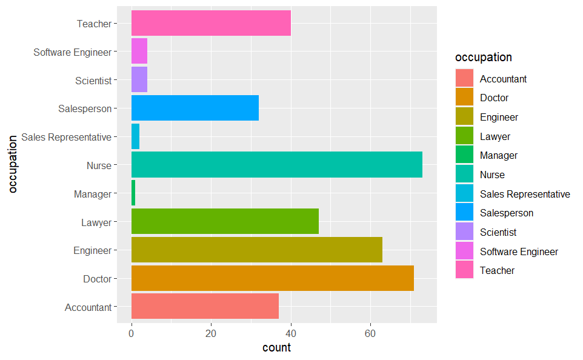

```r
df %>% ggplot(aes(occupation, fill=occupation)) + geom_bar()+ coord_flip()
```

- BMI category

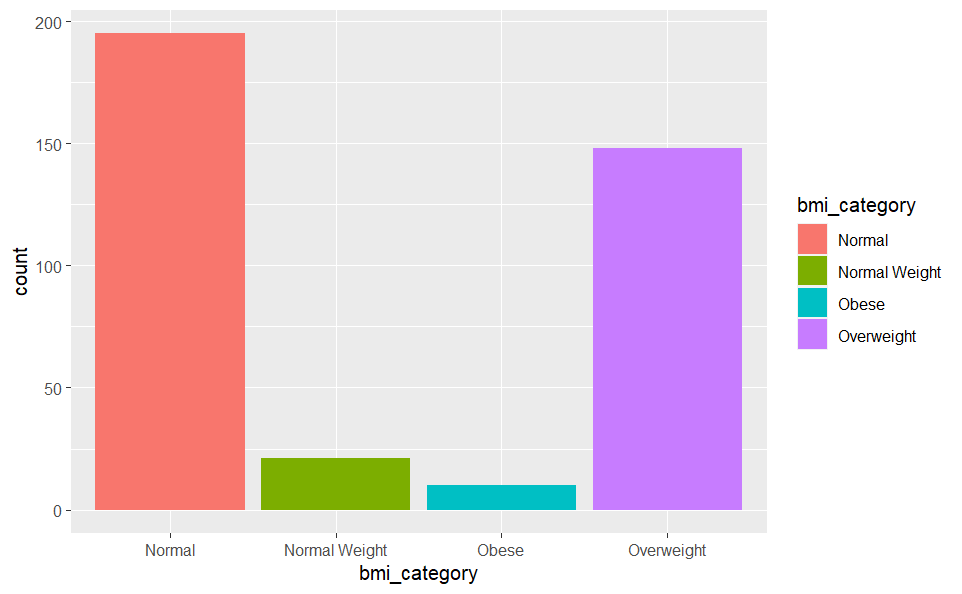

```r
df %>% ggplot(aes(bmi_category,fill=bmi_category)) + geom_bar()
```

We have two categories for normal weight. We will combine those into one.

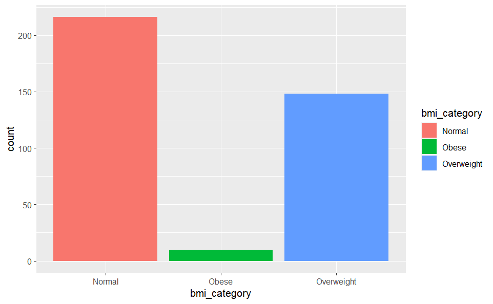

```r
df$bmi_category = ifelse(df$bmi_category=="Normal"|df$bmi_category=="Normal Weight", "Normal", df$bmi_category)
df %>% ggplot(aes(bmi_category,fill=bmi_category)) + geom_bar()
```

- Blood Pressure

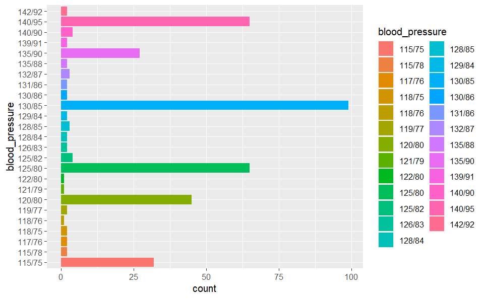

```r
df %>% ggplot(aes(blood_pressure, fill=blood_pressure)) + geom_bar() + coord_flip()
```

Majority of individuals in our dataset have a higher than normal blood pressure, above 120/80. We also have to transform this variable into three new categories: Normal, Elevated, and Hypertension. This will also improve the performance of our classification model.

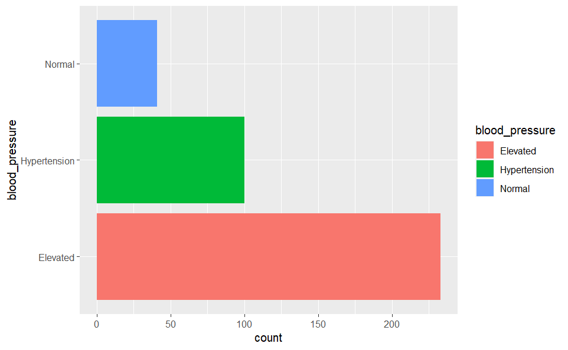

```r
df = df %>% separate_wider_delim(blood_pressure, delim ='/',names = c("systolic", "diastolic"))

df <- df %>% mutate(
  blood_pressure = case_when(
    as.numeric(systolic) < 120 & as.numeric(diastolic) < 80 ~ "Normal",
    as.numeric(systolic) >= 130 & as.numeric(diastolic) >= 89 ~ "Hypertension",
    TRUE ~ "Elevated"
  )
)

df %>% ggplot(aes(blood_pressure, fill=blood_pressure)) + geom_bar() + coord_flip()
```

This is consistent with our initial observation that the majority of dataset has higher than normal blood pressure.

- Sleep disorder (our target variable)

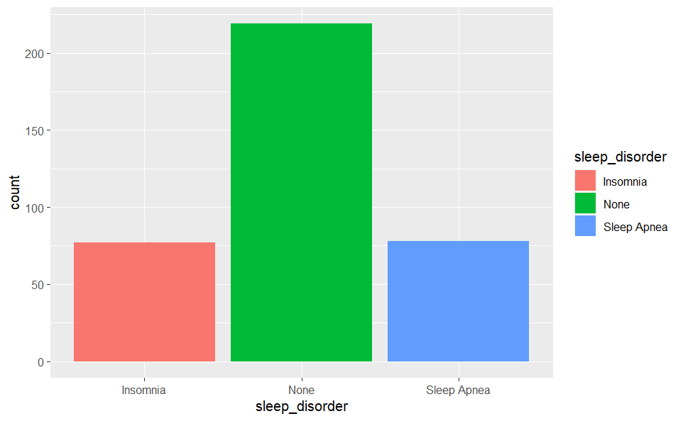

```r
df %>% ggplot(aes(sleep_disorder, fill=sleep_disorder)) + geom_bar()
```

Due to the size of our dataset, we will create a new target variable based on the sleep disorder variable. This will allow us to build a more robust model.

```r
# renaming "sleep_disorder" to "disorder_type"
df = df %>%
  rename(disorder_type = sleep_disorder) %>%
  mutate(sleep_disorder = ifelse(disorder_type=="Sleep Apnea"|disorder_type=="Insomnia","yes","no"))
unique(df$sleep_disorder)
```

```
[1] "no"  "yes"
```

```r
unique(df$disorder_type)
```

```
[1] "None"        "Sleep Apnea" "Insomnia"
```

Now sleep_disorder records whether an individual in our dataset has a sleep disorder or not.

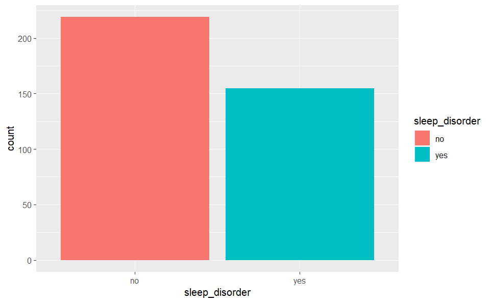

```r
df %>%
  ggplot(aes(x = sleep_disorder,fill = sleep_disorder)) +
  geom_bar()
```

```r
NA
```

Now, disorder_type records the type of disorder.

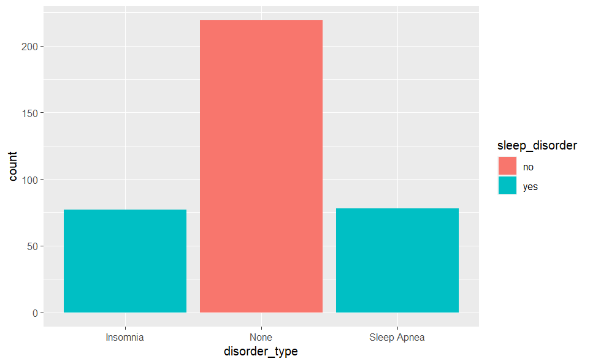

```r
df %>% ggplot(aes(disorder_type, fill=sleep_disorder)) + geom_bar()
```

**Now to the numerical variables**

- Age

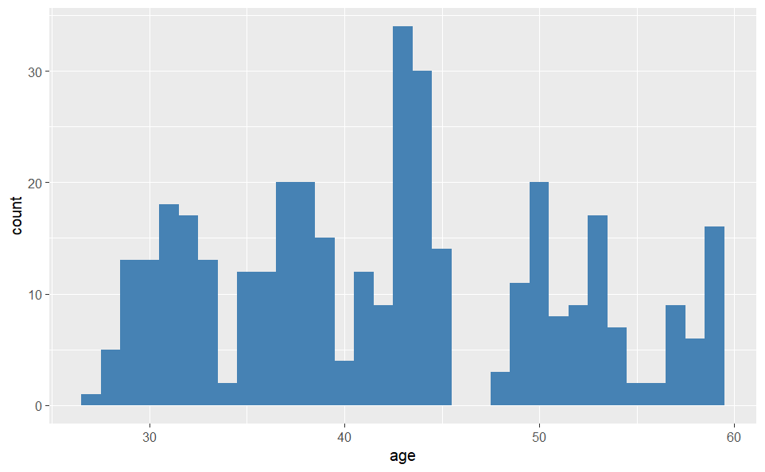

```r
df %>% ggplot(aes(age)) + geom_histogram(binwidth=1,fill="steelblue")
```

- Sleep duration

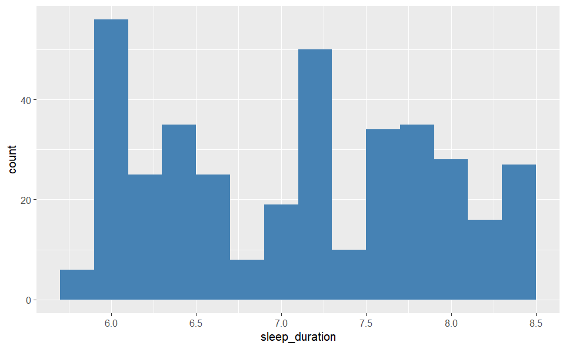

```r
df %>% ggplot(aes(sleep_duration)) + geom_histogram(binwidth=0.2,fill="steelblue")
```

- quality of sleep

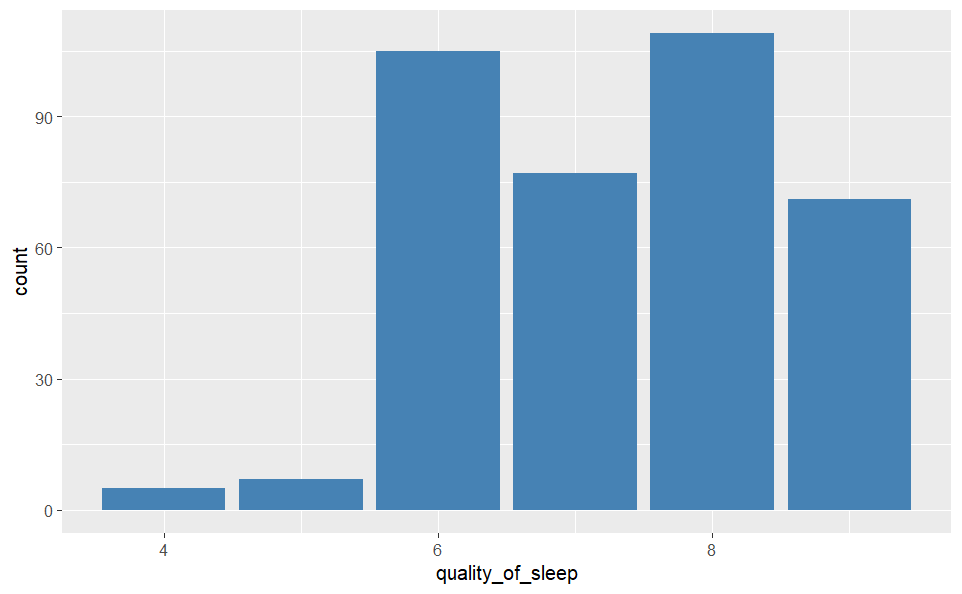

```r
df %>% ggplot(aes(quality_of_sleep)) + geom_bar(fill="steelblue")
```

- Physical activity level

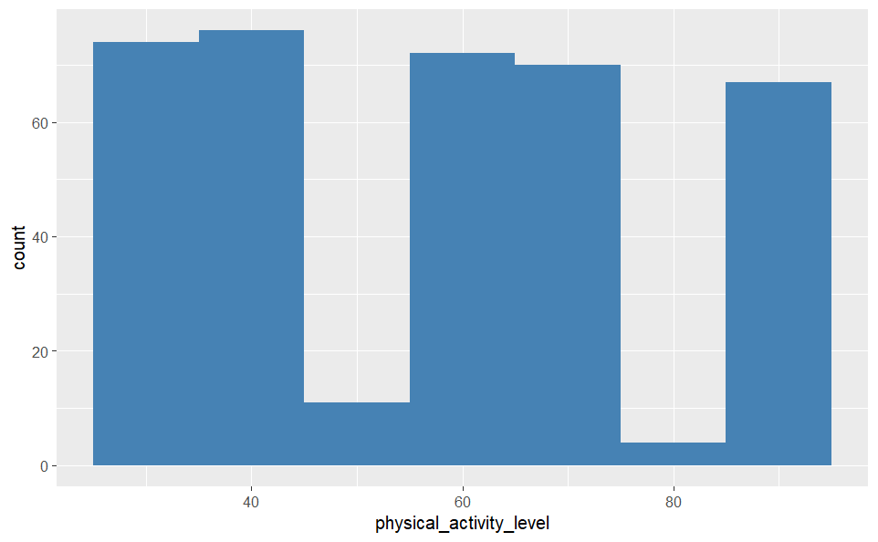

```r
df %>% ggplot(aes(physical_activity_level)) + geom_histogram(binwidth=10,fill="steelblue")
```

- Stress level

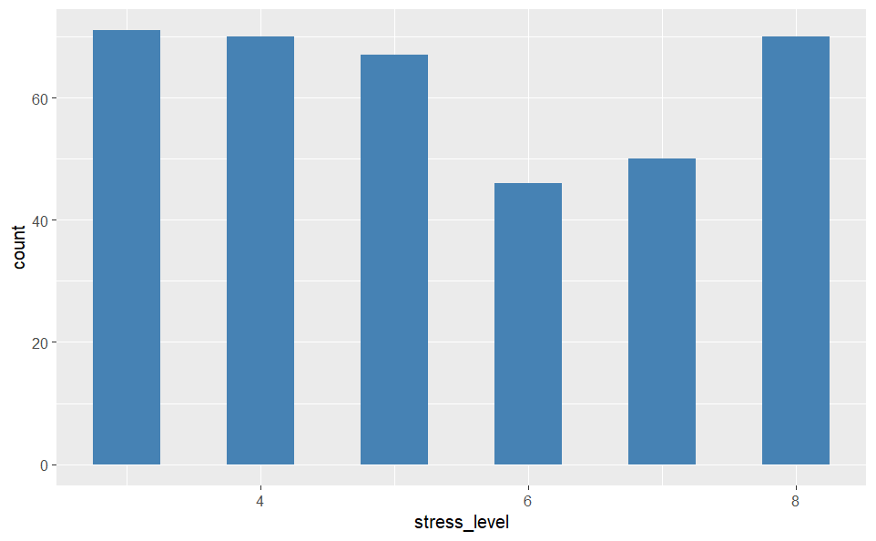

```r
df %>% ggplot(aes(stress_level)) + geom_histogram(binwidth=0.5, fill="steelblue")
```

- Heart rate

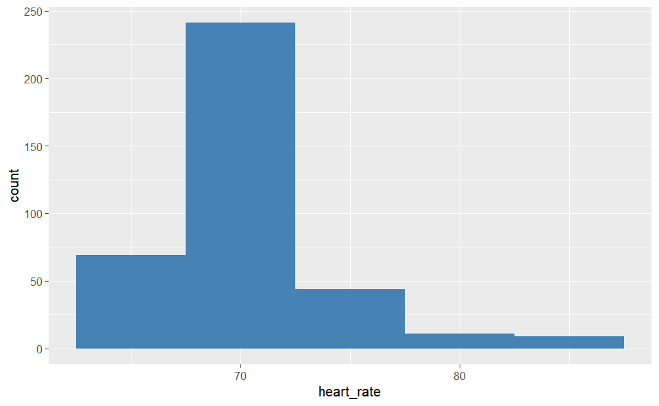

```r
df %>% ggplot(aes(heart_rate)) + geom_histogram(binwidth=5,fill="steelblue")
```

- Daily steps

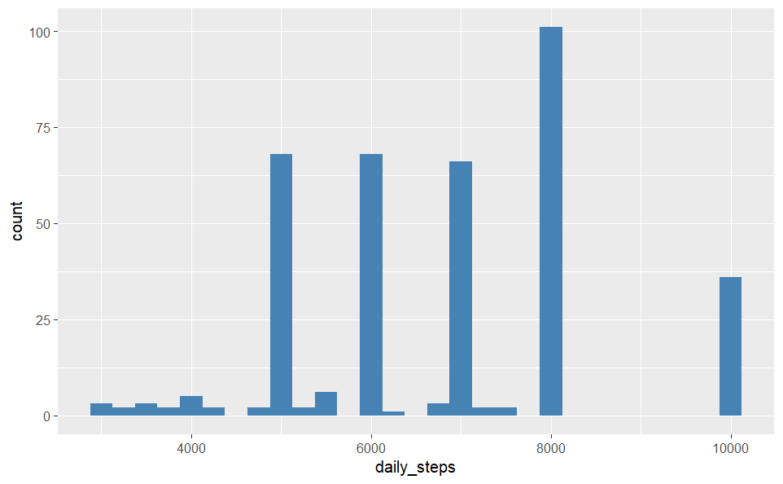

```r
df %>% ggplot(aes(daily_steps)) + geom_histogram(binwidth=250, fill="steelblue")
```

**Now let’s explore the relationship between all the variables in our dataset and our target variable.**

- Gender and sleep disorder

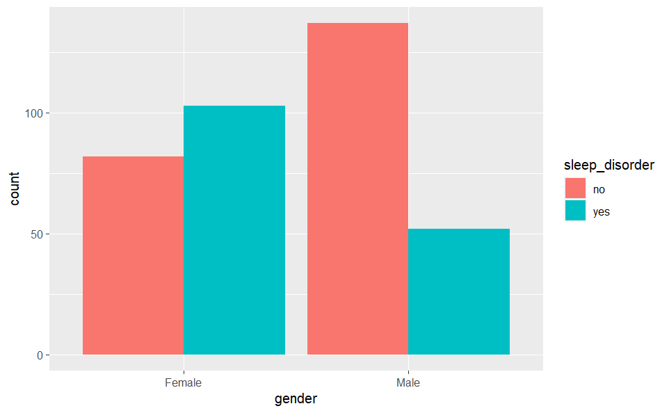

```r
df %>% ggplot(aes(gender, fill=sleep_disorder)) + geom_bar(position="dodge")
```

- Occupation and sleep disorder

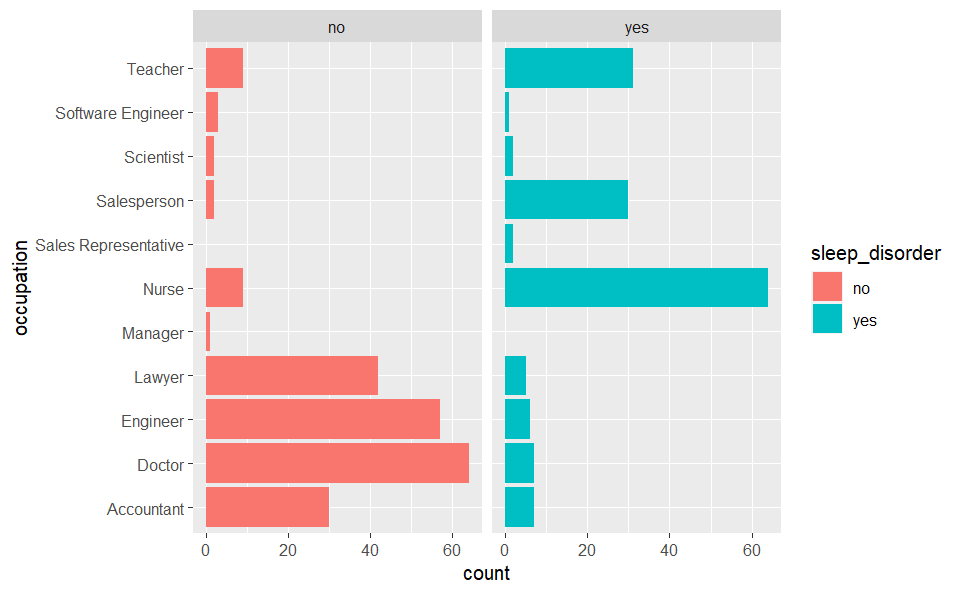

```r
df %>% ggplot(aes(occupation, fill=sleep_disorder)) + geom_bar(position="dodge") + facet_wrap(~sleep_disorder) + coord_flip()
```

- Blood pressure and sleep disorder

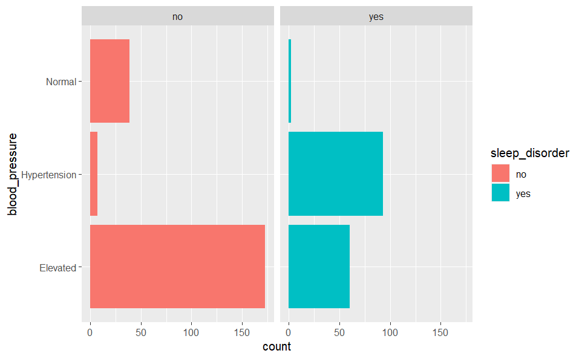

```r
df %>% ggplot(aes(blood_pressure, fill=sleep_disorder)) + geom_bar(position="dodge") + facet_wrap(~sleep_disorder) + coord_flip()
```

- BMI and sleep disorder

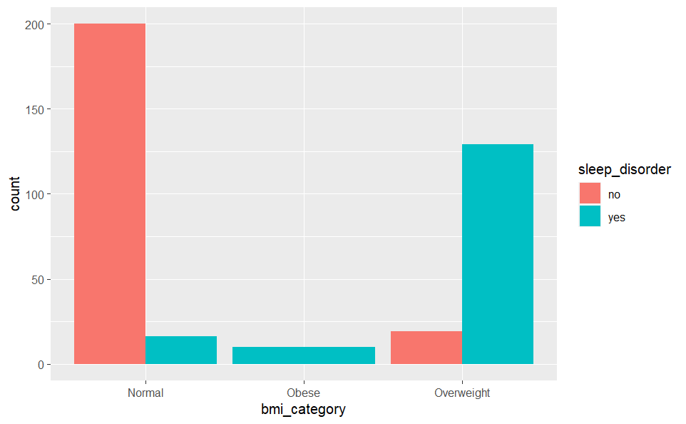

```r
df %>% ggplot(aes(bmi_category, fill=sleep_disorder)) + geom_bar(position="dodge")
```

- Age and sleep disorder

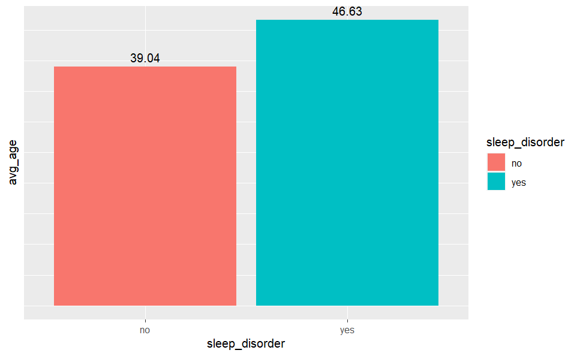

```r
df %>% group_by(sleep_disorder) %>%
  summarise(avg_age=mean(age)) %>%
  ggplot(aes(sleep_disorder, avg_age)) + geom_col(aes(fill=sleep_disorder)) +
  geom_text(aes(label=round(avg_age,2), vjust=-0.5)) +
  theme(axis.text.y = element_blank(),
        axis.ticks.y = element_blank())
```

- Sleep duration and sleep disorder

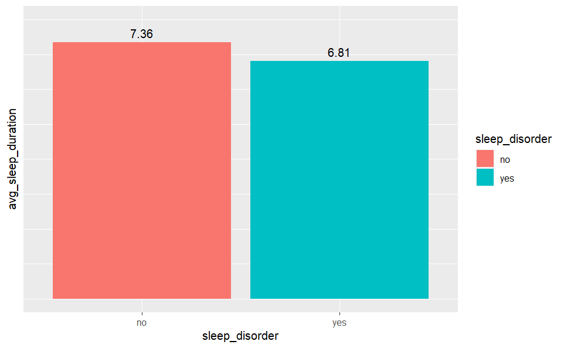

```r
df %>% group_by(sleep_disorder) %>%
  summarise(avg_sleep_duration=mean(sleep_duration)) %>%
  ggplot(aes(sleep_disorder,avg_sleep_duration)) + geom_col(aes(fill=sleep_disorder)) +
  geom_text(aes(label=round(avg_sleep_duration,2), vjust=-0.5)) +
  theme(axis.text.y = element_blank(),
        axis.ticks.y = element_blank())+
  ylim(0,8)
```

- Quality of sleep and sleep disorder

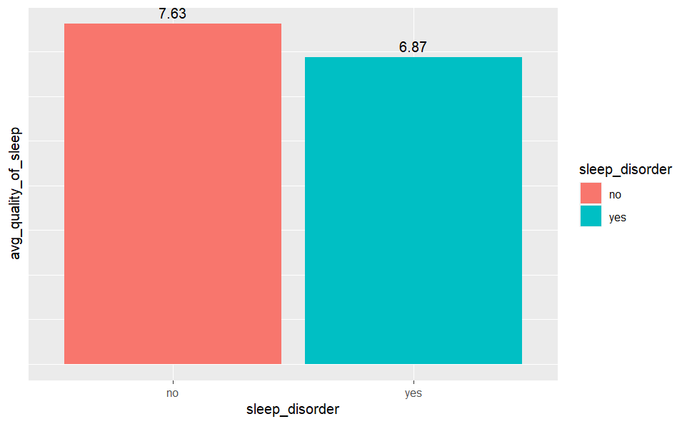

```r
df %>% group_by(sleep_disorder) %>%
  summarise(avg_quality_of_sleep=mean(quality_of_sleep)) %>%
  ggplot(aes(sleep_disorder, avg_quality_of_sleep)) + geom_col(aes(fill=sleep_disorder)) +
    geom_text(aes(label=round(avg_quality_of_sleep,2), vjust=-0.5)) +
  theme(axis.text.y = element_blank(),
        axis.ticks.y = element_blank())
```

- Physical activity level and sleep disorder

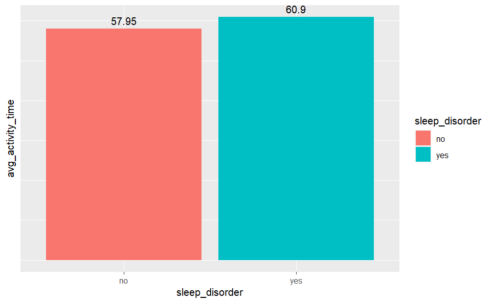

```r
df %>% group_by(sleep_disorder) %>%
  summarise(avg_activity_time=mean(physical_activity_level)) %>%
  ggplot(aes(sleep_disorder, avg_activity_time)) + geom_col(aes(fill=sleep_disorder)) +
    geom_text(aes(label=round(avg_activity_time,2), vjust=-0.5)) +
  theme(axis.text.y = element_blank(),
        axis.ticks.y = element_blank())
```

According to our dataset, people with sleep disorder, on average, spend more time being physically active than people without any sleep disorder.

- Stress level and sleep disorder

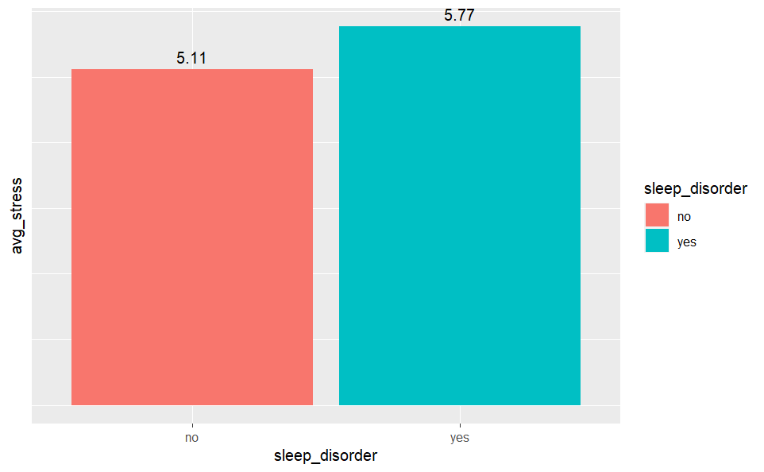

```r
df %>% group_by(sleep_disorder) %>%
  summarise(avg_stress=mean(stress_level)) %>%
  ggplot(aes(sleep_disorder, avg_stress)) + geom_col(aes(fill=sleep_disorder)) +
    geom_text(aes(label=round(avg_stress,2), vjust=-0.5)) +
  theme(axis.text.y = element_blank(),
        axis.ticks.y = element_blank())
```

- daily steps and sleep disorder

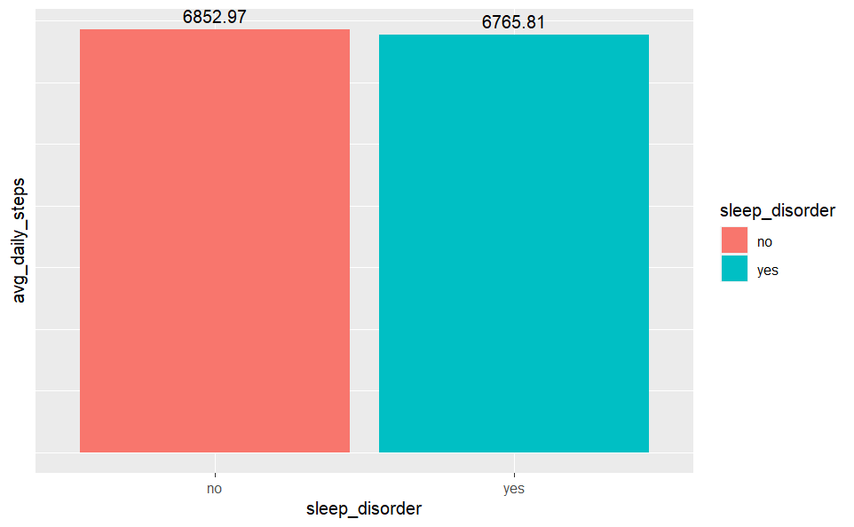

```r
df %>% group_by(sleep_disorder) %>%
  summarise(avg_daily_steps=mean(daily_steps)) %>%
  ggplot(aes(sleep_disorder, avg_daily_steps)) + geom_col(aes(fill=sleep_disorder)) +
    geom_text(aes(label=round(avg_daily_steps,2), vjust=-0.5)) +
  theme(axis.text.y = element_blank(),
        axis.ticks.y = element_blank())
```

With variables such as “physical activity & daily steps”, “quality of sleeps & sleep duration”, I suspect that we might have some correlated variables.

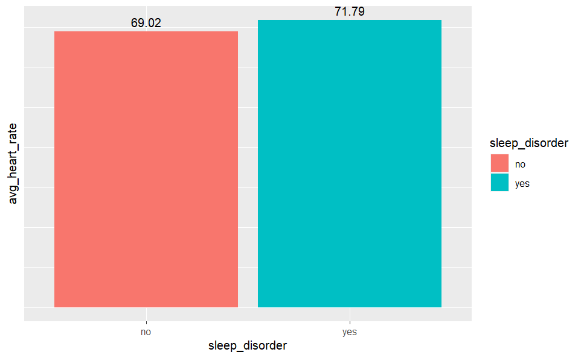

```r
df %>% group_by(sleep_disorder) %>%
  summarise(avg_heart_rate=mean(heart_rate)) %>%
  ggplot(aes(sleep_disorder, avg_heart_rate)) + geom_col(aes(fill=sleep_disorder)) +
    geom_text(aes(label=round(avg_heart_rate,2), vjust=-0.5)) +
  theme(axis.text.y = element_blank(),
        axis.ticks.y = element_blank())
```

So, let’s explore if any variables are correlated

```r
numerical_vars = subset(df, select = c(age, sleep_duration, quality_of_sleep, physical_activity_level, stress_level, heart_rate, daily_steps))

cor_matrix=cor(numerical_vars)
data.frame(cor_matrix)
```

|  | age | sleep_duration | quality_of_sleep | physical_activity_level | stress_level | heart_rate | daily_steps |
| --- | --- | --- | --- | --- | --- | --- | --- |
| age | 1.0000000 | 0.34470936 | 0.47373388 | 0.17899272 | -0.42234448 | -0.22560619 | 0.05797340 |
| sleep_duration | 0.3447094 | 1.00000000 | 0.88321300 | 0.21236031 | -0.81102303 | -0.51645489 | -0.03953254 |
| quality_of_sleep | 0.4737339 | 0.88321300 | 1.00000000 | 0.19289645 | -0.89875203 | -0.65986473 | 0.01679141 |
| physical_activity_level | 0.1789927 | 0.21236031 | 0.19289645 | 1.00000000 | -0.03413446 | 0.13697098 | 0.77272305 |
| stress_level | -0.4223445 | -0.81102303 | -0.89875203 | -0.03413446 | 1.00000000 | 0.67002646 | 0.18682895 |
| heart_rate | -0.2256062 | -0.51645489 | -0.65986473 | 0.13697098 | 0.67002646 | 1.00000000 | -0.03030858 |
| daily_steps | 0.0579734 | -0.03953254 | 0.01679141 | 0.77272305 | 0.18682895 | -0.03030858 | 1.00000000 |

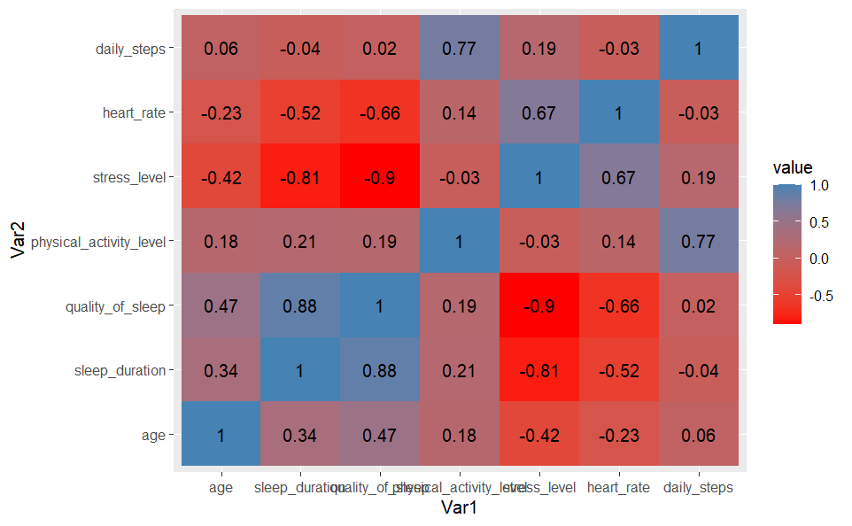

```r
melt_corMat = melt(cor_matrix)
melt_corMat %>% ggplot(aes(Var1, Var2, fill=value)) +
  geom_tile() +
  scale_fill_gradient(low="red", high="steelblue") +
  geom_text(aes(label=round(value,2)))
```

Here are the correlated variables:

- daily steps & physical_activity_level (0.77)
- heart rate & sleep duration (-0.52)
- heart rate & quality of sleep (-0.66)
- heart rate & stress level (0.67)
- stress level & sleep duration (-0.81)
- stress level & quality of sleep (-0.9)
- quality of sleep and sleep duration (0.88)

Considering the context of our analysis, we will prioritize measurement variables over the variables that represent subjective ratings.

Before we move onto modeling, we need to transform some variables into correct types.

```r
df$gender = as.factor(df$gender)
df$occupation = factor(df$occupation, levels = c("Doctor","Engineer","Lawyer","Accountant","Nurse","Teacher","Software Engineer","Scientist","Salesperson","Manager","Sales Representative"))
df$bmi_category = factor(df$bmi_category, levels = c("Normal", "Overweight", "Obese"))
df$sleep_disorder = as.factor(df$sleep_disorder)
# df$sleep_disorder = factor(df$sleep_disorder, levels = c("yes","no"))
df$blood_pressure = factor(df$blood_pressure,levels = c("Normal","Elevated", "Hypertension"))
```

```r
unique(df$gender)
```

```
[1] Male   Female
Levels: Female Male
```

```r
unique(df$occupation)
```

```
 [1] Software Engineer    Doctor               Sales Representative
 [4] Teacher              Nurse                Engineer
 [7] Accountant           Scientist            Lawyer
[10] Salesperson          Manager
11 Levels: Doctor Engineer Lawyer Accountant Nurse Teacher ... Sales Representative
```

```r
unique(df$bmi_category)
```

```
[1] Overweight Normal     Obese
Levels: Normal Overweight Obese
```

```r
unique(df$blood_pressure)
```

```
[1] Elevated     Hypertension Normal
Levels: Normal Elevated Hypertension
```

```r
unique(df$sleep_disorder)
```

```
[1] no  yes
Levels: no yes
```

```r
df = df %>% select(sleep_disorder, everything())
glimpse(df)
```

```
Rows: 374
Columns: 16
$ sleep_disorder          <fct> no, no, no, yes, yes, yes, yes, no, no, no, no, no…
$ person_id               <dbl> 1, 2, 3, 4, 5, 6, 7, 8, 9, 10, 11, 12, 13, 14, 15,…
$ gender                  <fct> Male, Male, Male, Male, Male, Male, Male, Male, Ma…
$ age                     <dbl> 27, 28, 28, 28, 28, 28, 29, 29, 29, 29, 29, 29, 29…
$ occupation              <fct> Software Engineer, Doctor, Doctor, Sales Represent…
$ sleep_duration          <dbl> 6.1, 6.2, 6.2, 5.9, 5.9, 5.9, 6.3, 7.8, 7.8, 7.8, …
$ quality_of_sleep        <dbl> 6, 6, 6, 4, 4, 4, 6, 7, 7, 7, 6, 7, 6, 6, 6, 6, 5,…
$ physical_activity_level <dbl> 42, 60, 60, 30, 30, 30, 40, 75, 75, 75, 30, 75, 30…
$ stress_level            <dbl> 6, 8, 8, 8, 8, 8, 7, 6, 6, 6, 8, 6, 8, 8, 8, 8, 7,…
$ bmi_category            <fct> Overweight, Normal, Normal, Obese, Obese, Obese, O…
$ systolic                <chr> "126", "125", "125", "140", "140", "140", "140", "…
$ diastolic               <chr> "83", "80", "80", "90", "90", "90", "90", "80", "8…
$ heart_rate              <dbl> 77, 75, 75, 85, 85, 85, 82, 70, 70, 70, 70, 70, 70…
$ daily_steps             <dbl> 4200, 10000, 10000, 3000, 3000, 3000, 3500, 8000, …
$ disorder_type           <chr> "None", "None", "None", "Sleep Apnea", "Sleep Apne…
$ blood_pressure          <fct> Elevated, Elevated, Elevated, Hypertension, Hypert…
```

Let’s drop the variables that we do not need

```r
df = df %>% select(-person_id, -systolic, -diastolic, -disorder_type)
```

Looking great! Now, off to modeling!

```r
# setting the seed
set.seed(12345)

# splitting the dataset
index = sample(nrow(df), nrow(df)*0.9, replace=FALSE)
train_df = df[index,]
validation_df = df[-index,]

# checking the proportions of the target variable for the train and testing sets
table(df$sleep_disorder)
```

```
 no yes
219 155
```

```r
prop.table(table(df$sleep_disorder))
```

```
       no       yes
0.5855615 0.4144385
```

```r
table(train_df$sleep_disorder)
```

```
 no yes
201 135
```

```r
prop.table(table(train_df$sleep_disorder))
```

```
       no       yes
0.5982143 0.4017857
```

```r
table(validation_df$sleep_disorder)
```

```
 no yes
 18  20
```

```r
prop.table(table(validation_df$sleep_disorder))
```

```
       no       yes
0.4736842 0.5263158
```

Due to our sample size, will use cross validation to train our model. But first, to simplify the feature selection process, we will use the random forest variable importance method to select the most important variables for our model.

```r
library(randomForest)
rf_model = randomForest(sleep_disorder~., data=train_df, importance=TRUE, ntree=100)
rf_varImp = importance(rf_model)
rf_varImp <- data.frame(Feature=rownames(rf_varImp), Importance=rf_varImp[,1])
rf_varImp$Importance <- round(rf_varImp$Importance / max(rf_varImp$Importance) * 100, 2)
rf_varImp <- rf_varImp[order(rf_varImp$Importance, decreasing = TRUE), ]
rf_varImp
```

|  | Feature | Importance |
| --- | --- | --- |
| bmi_category | bmi_category | 100.00 |
| occupation | occupation | 70.70 |
| sleep_duration | sleep_duration | 65.63 |
| blood_pressure | blood_pressure | 62.91 |
| heart_rate | heart_rate | 55.86 |
| stress_level | stress_level | 54.29 |
| daily_steps | daily_steps | 45.75 |
| quality_of_sleep | quality_of_sleep | 34.86 |
| age | age | 22.32 |
| gender | gender | 19.50 |

[output cut: 1 more lines]

**First model -** removing variables representing a subjective rating(view data dictionary)

```r
# type of training method and number of folds
train_specs = trainControl(method = "cv", number=10,
                           savePredictions = "all",
                           classProbs = TRUE)

# model specification
formula = sleep_disorder ~ bmi_category+occupation+sleep_duration+blood_pressure+daily_steps
model1 = train(formula, data=train_df,
               method="glm", family="binomial",
               trControl=train_specs)
print(model1)
```

```
Generalized Linear Model

336 samples
  5 predictor
  2 classes: 'no', 'yes'

No pre-processing
Resampling: Cross-Validated (10 fold)
Summary of sample sizes: 302, 303, 303, 302, 302, 302, ...
Resampling results:

  Accuracy   Kappa
  0.9136364  0.8201622
```

```r
summary(model1)
```

```
Call:
NULL

Coefficients:
                                   Estimate Std. Error z value Pr(>|z|)
(Intercept)                       1.036e+00  3.667e+00   0.283  0.77754
bmi_categoryOverweight            1.317e+00  9.226e-01   1.427  0.15360
bmi_categoryObese                 3.129e+01  2.587e+03   0.012  0.99035
occupationEngineer                1.886e+00  1.078e+00   1.749  0.08027 .
occupationLawyer                  1.349e+00  1.214e+00   1.111  0.26646
occupationAccountant              3.680e+00  1.578e+00   2.333  0.01966 *
occupationNurse                   3.665e+00  1.105e+00   3.317  0.00091 ***
occupationTeacher                 2.973e+00  1.231e+00   2.414  0.01577 *
`occupationSoftware Engineer`    -1.471e+01  1.744e+03  -0.008  0.99327
occupationScientist               1.438e+00  1.544e+00   0.932  0.35155
occupationSalesperson             5.074e+00  1.561e+00   3.250  0.00115 **
occupationManager                -1.635e+01  6.523e+03  -0.003  0.99800
`occupationSales Representative` -1.225e+01  5.288e+03  -0.002  0.99815
sleep_duration                   -8.268e-01  3.933e-01  -2.102  0.03552 *
blood_pressureElevated            2.223e+00  1.528e+00   1.454  0.14584
blood_pressureHypertension        3.961e+00  1.944e+00   2.038  0.04157 *
daily_steps                      -1.968e-04  2.016e-04  -0.976  0.32909
---
Signif. codes:  0 ‘***’ 0.001 ‘**’ 0.01 ‘*’ 0.05 ‘.’ 0.1 ‘ ’ 1

(Dispersion parameter for binomial family taken to be 1)

    Null deviance: 452.75  on 335  degrees of freedom
Residual deviance: 157.31  on 319  degrees of freedom
AIC: 191.31

Number of Fisher Scoring iterations: 17
```

Let’s replace daily steps with physical activity level because it will be easier to interpret.

```r
formula = sleep_disorder ~ bmi_category+occupation+sleep_duration+blood_pressure+physical_activity_level
model2 = train(formula, data=train_df,
               method="glm", family="binomial",
               trControl=train_specs)
print(model2)
```

```
Generalized Linear Model

336 samples
  5 predictor
  2 classes: 'no', 'yes'

No pre-processing
Resampling: Cross-Validated (10 fold)
Summary of sample sizes: 301, 303, 302, 302, 302, 303, ...
Resampling results:

  Accuracy   Kappa
  0.9254749  0.8448358
```

```r
summary(model2)
```

```
Call:
NULL

Coefficients:
                                   Estimate Std. Error z value Pr(>|z|)
(Intercept)                        -0.37887    3.30364  -0.115 0.908697
bmi_categoryOverweight              1.41231    0.92489   1.527 0.126760
bmi_categoryObese                  31.90536 2587.54959   0.012 0.990162
occupationEngineer                  1.90394    1.08371   1.757 0.078939 .
occupationLawyer                    1.14128    1.18449   0.964 0.335287
occupationAccountant                3.64334    1.56584   2.327 0.019978 *
occupationNurse                     3.78320    1.09940   3.441 0.000579 ***
occupationTeacher                   3.10545    1.21871   2.548 0.010830 *
`occupationSoftware Engineer`     -14.48517 1751.45049  -0.008 0.993401
occupationScientist                 1.50550    1.54122   0.977 0.328656
occupationSalesperson               5.01531    1.55210   3.231 0.001232 **
occupationManager                 -16.27316 6522.63872  -0.002 0.998009
`occupationSales Representative`  -12.02331 5288.46088  -0.002 0.998186
sleep_duration                     -0.75466    0.39625  -1.904 0.056845 .
blood_pressureElevated              2.30592    1.54165   1.496 0.134718
blood_pressureHypertension          3.74726    1.91793   1.954 0.050724 .
physical_activity_level            -0.00773    0.01590  -0.486 0.626978
---
Signif. codes:  0 ‘***’ 0.001 ‘**’ 0.01 ‘*’ 0.05 ‘.’ 0.1 ‘ ’ 1

(Dispersion parameter for binomial family taken to be 1)

    Null deviance: 452.75  on 335  degrees of freedom
Residual deviance: 158.05  on 319  degrees of freedom
AIC: 192.05

Number of Fisher Scoring iterations: 17
```

We can’t add any other variables except age and gender because all the other other variables are strongly correlated with the variables already present in the model. So, let’s try adding the “age” and “gender” and analyze their impact on the model’s performance.

```r
# model specification
formula = sleep_disorder ~ bmi_category+occupation+sleep_duration+blood_pressure+physical_activity_level+age+gender
model3 = train(formula, data=train_df,
               method="glm", family="binomial",
               trControl=train_specs)
print(model3)
```

```
Generalized Linear Model

336 samples
  7 predictor
  2 classes: 'no', 'yes'

No pre-processing
Resampling: Cross-Validated (10 fold)
Summary of sample sizes: 302, 301, 302, 302, 302, 303, ...
Resampling results:

  Accuracy   Kappa
  0.9103285  0.8132251
```

```r
summary(model3)
```

```
Call:
NULL

Coefficients:
                                   Estimate Std. Error z value Pr(>|z|)
(Intercept)                      -5.387e-02  3.687e+00  -0.015  0.98834
bmi_categoryOverweight            1.141e+00  1.204e+00   0.947  0.34350
bmi_categoryObese                 3.197e+01  2.643e+03   0.012  0.99035
occupationEngineer                1.812e+00  1.227e+00   1.478  0.13952
occupationLawyer                  1.081e+00  1.244e+00   0.869  0.38500
occupationAccountant              3.428e+00  2.036e+00   1.683  0.09235 .
occupationNurse                   3.841e+00  1.660e+00   2.313  0.02072 *
occupationTeacher                 3.311e+00  1.641e+00   2.018  0.04357 *
`occupationSoftware Engineer`    -1.417e+01  1.787e+03  -0.008  0.99367
occupationScientist               1.769e+00  2.423e+00   0.730  0.46535
occupationSalesperson             4.854e+00  1.621e+00   2.995  0.00274 **
occupationManager                -1.625e+01  6.523e+03  -0.002  0.99801
`occupationSales Representative` -1.175e+01  5.316e+03  -0.002  0.99824
sleep_duration                   -9.768e-01  5.912e-01  -1.652  0.09851 .
blood_pressureElevated            2.024e+00  1.616e+00   1.253  0.21017
blood_pressureHypertension        3.180e+00  2.170e+00   1.466  0.14273
physical_activity_level          -6.907e-03  1.969e-02  -0.351  0.72571
age                               3.770e-02  7.536e-02   0.500  0.61686
genderMale                        1.350e-01  1.260e+00   0.107  0.91467
---
Signif. codes:  0 ‘***’ 0.001 ‘**’ 0.01 ‘*’ 0.05 ‘.’ 0.1 ‘ ’ 1

(Dispersion parameter for binomial family taken to be 1)

    Null deviance: 452.75  on 335  degrees of freedom
Residual deviance: 157.76  on 317  degrees of freedom
AIC: 195.76

Number of Fisher Scoring iterations: 17
```

No significant improvements from the addition of gender to our model. Plus gender and age are not statistically significant.

Summary of our models

```r
# Create an empty dataframe to store the results
results_df <- data.frame(Model = character(),
                         Accuracy = numeric(),
                         Kappa = numeric(),
                         AIC = numeric(),
                         stringsAsFactors = FALSE)

# Loop through each model
n=3
for (i in 1:n) {
  # Get the model object
  model <- get(paste0("model", i))

  # Extract the accuracy, kappa, and AIC values
  accuracy <- model[["results"]][["Accuracy"]]
  kappa <- model[["results"]][["Kappa"]]
  aic <- model[["finalModel"]][["aic"]]

  # Create a row of data with the model name and the corresponding values
  row <- data.frame(Model = paste0("model", i),
                    Accuracy = accuracy,
                    Kappa = kappa,
                    AIC = aic)

  # Append the row to the results dataframe
  results_df <- rbind(results_df, row)
}

# Print the results dataframe
results_df
```

| Model | Accuracy | Kappa | AIC |
| --- | --- | --- | --- |
| model1 | 0.9136364 | 0.8201622 | 191.3139 |
| model2 | 0.9254749 | 0.8448358 | 192.0543 |
| model3 | 0.9103285 | 0.8132251 | 195.7643 |

```r
NA
```

Model 2 has higher accuracy and kappa score. However, this model is affected by the presence of too many predictor variables which is evident in the higher AIC score.

All three models would work great. However, we will go with the second model because of its overall good performance.

Let’s test the performance of the model on new data.

```r
prediction = predict(model2, newdat=validation_df %>% select(-sleep_disorder))
confusionMatrix(prediction,validation_df$sleep_disorder)
```

```
Confusion Matrix and Statistics

          Reference
Prediction no yes
       no  17   3
       yes  1  17

               Accuracy : 0.8947
                 95% CI : (0.752, 0.9706)
    No Information Rate : 0.5263
    P-Value [Acc > NIR] : 1.41e-06

                  Kappa : 0.7901

 Mcnemar's Test P-Value : 0.6171

            Sensitivity : 0.9444
            Specificity : 0.8500
         Pos Pred Value : 0.8500
         Neg Pred Value : 0.9444
             Prevalence : 0.4737
         Detection Rate : 0.4474
   Detection Prevalence : 0.5263
      Balanced Accuracy : 0.8972

       'Positive' Class : no
```

This model has an 89% accuracy on the validation data. It also has high sensitivity and specificity. This means that it can accurately identified 94% of the individuals without any sleep issues and 85% of individuals with sleep issues.

**Interpretation of the model’s coefficients**

```r
# getting the estimates into table
coef = as.data.frame(model2[["finalModel"]][["coefficients"]])
coef$coefficients = coef$`model2[["finalModel"]][["coefficients"]]`
coef = cbind(rownames(coef),coef$coefficients)
coef = as.data.frame(coef)
coef = coef %>% rename(
  variables = V1,
  log_odds = V2
)

# creating new columns
coef = coef %>% mutate(
  log_odds = as.numeric(as.character(log_odds)),
  odd_ratio = exp(log_odds),
  percentage_change = (1 - exp((log_odds))),
  log_odds = round(log_odds,2),
  odd_ratio = round(odd_ratio,2),
  percentage_change = paste0(round(percentage_change,2),"%"))


coef = coef[-1,]
coef
```

|  | variables | log_odds | odd_ratio | percentage_change |
| --- | --- | --- | --- | --- |
| 2 | bmi_categoryOverweight | 1.41 | 4.110000e+00 | -3.11% |
| 3 | bmi_categoryObese | 31.91 | 7.183279e+13 | -71832792624199.4% |
| 4 | occupationEngineer | 1.90 | 6.710000e+00 | -5.71% |
| 5 | occupationLawyer | 1.14 | 3.130000e+00 | -2.13% |
| 6 | occupationAccountant | 3.64 | 3.822000e+01 | -37.22% |
| 7 | occupationNurse | 3.78 | 4.396000e+01 | -42.96% |
| 8 | occupationTeacher | 3.11 | 2.232000e+01 | -21.32% |
| 9 | `occupationSoftware Engineer` | -14.49 | 0.000000e+00 | 1% |
| 10 | occupationScientist | 1.51 | 4.510000e+00 | -3.51% |
| 11 | occupationSalesperson | 5.02 | 1.507000e+02 | -149.7% |

[output cut: 6 more lines]

- **BMI**

According to our data, the log odds of having a sleep disorder for a person who is overweight is 1.41 times the odds of a person of normal weight. The odds ratio of a person who is overweight are 4.11 times those of a person of normal weight. So, a person who is overweight is 3.11% more likely to have a sleep disorder relative to a person of normal weight.

- **Occupation**

Doctors had the highest number of individuals without any sleep disorders among all categories. Thus, were used as our reference category.

Our findings indicate that, compared to doctors, engineers have a log odds of having a sleep disorder that is 1.9 times the odds of individuals in other occupations. The odds ratio for engineers is 6.71, implying that they have 6.71 times the odds of developing a sleep disorder compared to doctors. This represents a percentage change of -5.71%, meaning that engineers are 5.71% more likely to have a sleep disorder than individuals in other professions.

The log odds of having a sleep disorder for managers have a log odds of having a sleep disorder that is -16.27 times the odds for doctors. The odds ratio for managers is 0, indicating that they have zero odds of developing a sleep disorder compared to doctors. This corresponds to a percentage change of 1.00%, suggesting that managers are 1% less likely to have a sleep disorder relative to doctors.

In summary, certain occupations such as Engineers, lawyers, accountants, nurses, teachers, scientists, and salespeople have a higher likelihood, in varying percentages, of having a sleep disorder relative to doctors having the same sleep disorder. Whereas occupations such as Software Engineers, Managers, and Sales Representatives have a lower likelihood of having a sleep disorder relative to doctors.

- **Sleep Duration**

Based on our data, for each unit increase in sleep duration, the log odds of having a sleep disorder decrease by a factor of -0.75. The odds ratio for sleep duration is 0.47, indicating that with each unit increase in sleep duration, the odds of having a sleep disorder decrease by a factor of 0.47. This corresponds to a percentage change of 0.53%, suggesting that longer sleep duration is associated with a 0.53% reduction in the likelihood of experiencing a sleep disorder.

- **Blood Pressure — Elevated**

Our findings indicate that the log odds of having a sleep disorder for individuals with elevated blood pressure are 2.31 times the log odds of individuals with normal blood pressure. The odds ratio for elevated blood pressure is 10.03, suggesting that individuals with elevated blood pressure have 10.03 times the odds of developing a sleep disorder compared to individuals with normal blood pressure. This corresponds to a percentage change of -9.03%, indicating that elevated blood pressure increases the likelihood of having a sleep disorder by 9.03%.

- **Physical Activity Level**

Based on our findings, for each unit increase in physical activity level, which is the number of minutes spent on physical activities daily, the log odds of having a sleep disorder decrease by a factor of 0.01. The odds ratio for physical activity level is 0.99, indicating that with each unit increase in physical activity level, the odds of having a sleep disorder decrease by a factor of 0.99. This corresponds to a percentage change of 0.01%, suggesting that higher physical activity levels reduced the likelihood of experiencing a sleep disorder by 0.01%.

In conclusion, these variables prove to be effective in identifying individuals with sleep disorders. With additional data, it may be possible to utilize these variables in an attempt to identify specific types of sleep disorders that individuals may have.